# Decision Trees and Random Forests

*Problem Statement:* *This project involves building decision tree and random forest models to answer a number of questions. We will use the Carseats dataset that is part of the ISLR package.*

**Loading Required Libraries**

```r
library(ISLR)

library(dplyr)

library(glmnet)

library(caret)

library(rpart)

library(rpart.plot)

library(rattle)
```

```r
summary(Carseats)
```

```
##      Sales          CompPrice       Income        Advertising
##  Min.   : 0.000   Min.   : 77   Min.   : 21.00   Min.   : 0.000
##  1st Qu.: 5.390   1st Qu.:115   1st Qu.: 42.75   1st Qu.: 0.000
##  Median : 7.490   Median :125   Median : 69.00   Median : 5.000
##  Mean   : 7.496   Mean   :125   Mean   : 68.66   Mean   : 6.635
##  3rd Qu.: 9.320   3rd Qu.:135   3rd Qu.: 91.00   3rd Qu.:12.000
##  Max.   :16.270   Max.   :175   Max.   :120.00   Max.   :29.000
##    Population        Price        ShelveLoc        Age          Education
##  Min.   : 10.0   Min.   : 24.0   Bad   : 96   Min.   :25.00   Min.   :10.0
##  1st Qu.:139.0   1st Qu.:100.0   Good  : 85   1st Qu.:39.75   1st Qu.:12.0
##  Median :272.0   Median :117.0   Medium:219   Median :54.50   Median :14.0
##  Mean   :264.8   Mean   :115.8                Mean   :53.32   Mean   :13.9
##  3rd Qu.:398.5   3rd Qu.:131.0                3rd Qu.:66.00   3rd Qu.:16.0
##  Max.   :509.0   Max.   :191.0                Max.   :80.00   Max.   :18.0
##  Urban       US
##  No :118   No :142
##  Yes:282   Yes:258
##
##
##
##
```

**Selecting required attributes**

```r
Carseats_Filtered = Carseats %>% select("Sales", "Price",
"Advertising","Population","Age","Income","Education")
summary(Carseats_Filtered)
```

```
##      Sales            Price        Advertising       Population
##  Min.   : 0.000   Min.   : 24.0   Min.   : 0.000   Min.   : 10.0
##  1st Qu.: 5.390   1st Qu.:100.0   1st Qu.: 0.000   1st Qu.:139.0
##  Median : 7.490   Median :117.0   Median : 5.000   Median :272.0
##  Mean   : 7.496   Mean   :115.8   Mean   : 6.635   Mean   :264.8
##  3rd Qu.: 9.320   3rd Qu.:131.0   3rd Qu.:12.000   3rd Qu.:398.5
##  Max.   :16.270   Max.   :191.0   Max.   :29.000   Max.   :509.0
##       Age            Income         Education
##  Min.   :25.00   Min.   : 21.00   Min.   :10.0
##  1st Qu.:39.75   1st Qu.: 42.75   1st Qu.:12.0
##  Median :54.50   Median : 69.00   Median :14.0
##  Mean   :53.32   Mean   : 68.66   Mean   :13.9
##  3rd Qu.:66.00   3rd Qu.: 91.00   3rd Qu.:16.0
##  Max.   :80.00   Max.   :120.00   Max.   :18.0
```

**Developing a decision tree regression model to forecast Sales using required attributes.(“Price”, “Advertising”, “Population”, “Age”, “Income” and “Education”).**

```r
model_1 = rpart(Sales~.,data=Carseats_Filtered,method = 'anova')
summary(model_1)
```

```
## Call:
## rpart(formula = Sales ~ ., data = Carseats_Filtered, method = "anova")
##   n= 400
##
##            CP nsplit rel error    xerror       xstd
## 1  0.14251535      0 1.0000000 1.0016660 0.06911645
## 2  0.08034146      1 0.8574847 0.8963677 0.06448264
## 3  0.06251702      2 0.7771432 0.8756942 0.06570530
## 4  0.02925241      3 0.7146262 0.8491096 0.05905742
## 5  0.02537341      4 0.6853738 0.8840246 0.05958575
## 6  0.02127094      5 0.6600003 0.8775057 0.05946110
## 7  0.02059174      6 0.6387294 0.8681534 0.05834355
## 8  0.01632010      7 0.6181377 0.8722918 0.05883380
## 9  0.01521801      8 0.6018176 0.8842553 0.05968412
## 10 0.01042023      9 0.5865996 0.9029342 0.06262118
## 11 0.01000559     10 0.5761793 0.9045526 0.06103937
## 12 0.01000000     12 0.5561681 0.8965813 0.06083282
##
## Variable importance
##       Price Advertising         Age      Income  Population   Education
##          49          18          16           8           6           3
##
## Node number 1: 400 observations,    complexity param=0.1425153
##   mean=7.496325, MSE=7.955687
##   left son=2 (329 obs) right son=3 (71 obs)
##   Primary splits:
##       Price       < 94.5  to the right, improve=0.14251530, (0 missing)
##       Advertising < 7.5   to the left,  improve=0.07303226, (0 missing)
##       Age         < 61.5  to the right, improve=0.07120203, (0 missing)
##       Income      < 61.5  to the left,  improve=0.02840494, (0 missing)
##       Population  < 174.5 to the left,  improve=0.01077467, (0 missing)
##
## Node number 2: 329 observations,    complexity param=0.08034146
##   mean=7.001672, MSE=6.815199
##   left son=4 (174 obs) right son=5 (155 obs)
##   Primary splits:
##       Advertising < 6.5   to the left,  improve=0.11402580, (0 missing)
##       Price       < 136.5 to the right, improve=0.08411056, (0 missing)
##       Age         < 63.5  to the right, improve=0.08091745, (0 missing)
##       Income      < 60.5  to the left,  improve=0.03394126, (0 missing)
```

[output cut: 161 more lines]

```
##   Surrogate splits:
##       Education   < 12.5  to the right, agree=0.676, adj=0.267, (0 split)
##       Advertising < 7.5   to the right, agree=0.647, adj=0.200, (0 split)
##       Age         < 53.5  to the left,  agree=0.647, adj=0.200, (0 split)
##       Population  < 240   to the right, agree=0.618, adj=0.133, (0 split)
##       Income      < 41.5  to the right, agree=0.618, adj=0.133, (0 split)
##
## Node number 47: 64 observations
##   mean=9.529375, MSE=4.5078
##
## Node number 92: 19 observations
##   mean=6.751053, MSE=3.378915
##
## Node number 93: 15 observations
##   mean=9.154667, MSE=3.273025
```

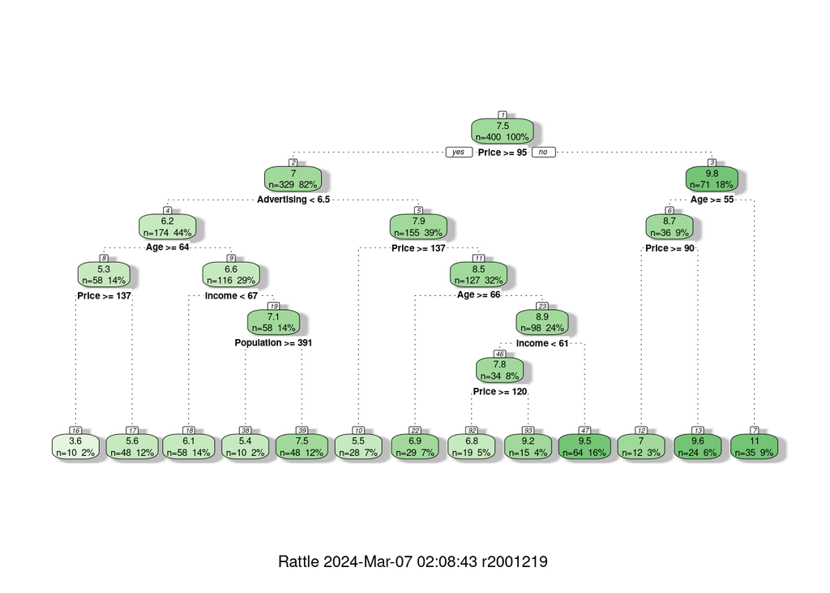

```r
fancyRpartPlot(model_1)
```

*The price attribute is utilized at the root node of the tree for the purpose of splitting.*

**Considering the following input: Sales=15,Price=8.71,Population=120,Advertising=0,Age=71,Income= 110,Education=10.Estimating Sales for this record using the decision tree model**

```r
prediction_data = data.frame(Price=8.71,Population=120,Advertising=0,Age=71
,Income= 110, Education= 10)


prediction<- predict(model_1,prediction_data)

prediction
```

```
##       1
## 9.58625
```

*Predicted sales value for this record is 9.58625.*

**Using the caret function to train a random forest (method=’rf’) for the same dataset.**

```r
set.seed(123)
model_2 <- train(Sales~.,
               data= Carseats_Filtered,
               method = "rf")

# Print the results
model_2
```

```
## Random Forest
##
## 400 samples
##   6 predictor
##
## No pre-processing
## Resampling: Bootstrapped (25 reps)
## Summary of sample sizes: 400, 400, 400, 400, 400, 400, ...
## Resampling results across tuning parameters:
##
##   mtry  RMSE      Rsquared   MAE
##   2     2.405819  0.2852547  1.926801
##   4     2.421577  0.2790266  1.934608
##   6     2.447373  0.2681323  1.953147
##
## RMSE was used to select the optimal model using the smallest value.
## The final value used for the model was mtry = 2.
```

*Best results are obtained when mtry value is set to be 2.*

**Customizing the search grid by checking the model’s performance for mtry values of 2, 3 and 5 using 3 repeats of 5-fold cross validation.**

```r
set.seed(123)

#Cross-Validation
control <- trainControl(method = "repeatedcv",
                     repeats = 3,
                     number = 5)

#Defining search grid with mtry values of 2,3,5
search_grid <- expand.grid(mtry = c(2, 3, 5))


# Training the model using the search grid and cross-validation
model <- train(Sales~., Carseats_Filtered,method = "rf",tuneGrid = search_grid,trControl = control)
print(model)
```

```
## Random Forest
##
## 400 samples
##   6 predictor
##
## No pre-processing
## Resampling: Cross-Validated (5 fold, repeated 3 times)
## Summary of sample sizes: 320, 321, 319, 320, 320, 319, ...
## Resampling results across tuning parameters:
##
##   mtry  RMSE      Rsquared   MAE
##   2     2.405235  0.2813795  1.930855
##   3     2.401365  0.2858295  1.920612
##   5     2.417771  0.2821938  1.934886
##
## RMSE was used to select the optimal model using the smallest value.
## The final value used for the model was mtry = 3.
```